# valerie-kagglechallenge-notebook (1)

```python
#RowNumber, CustomerId and surname are unique hence dropping it
df1_train = df_train.drop(['id', 'clean_title'], axis=1)
```

The unique features 'Id' and 'clean title' on the train dataframe have been dropped

```python
#RowNumber, CustomerId and surname are unique hence dropping it
df_test = df_test.drop(['clean_title'], axis=1)
```

```python
df1_train.info()
```

```
<class 'pandas.core.frame.DataFrame'>
RangeIndex: 54273 entries, 0 to 54272
Data columns (total 11 columns):
 #   Column        Non-Null Count  Dtype
---  ------        --------------  -----
 0   brand         54273 non-null  object
 1   model         54273 non-null  object
 2   model_year    54273 non-null  int64
 3   milage        54273 non-null  int64
 4   fuel_type     54273 non-null  object
 5   engine        54273 non-null  object
 6   transmission  54273 non-null  object
 7   ext_col       54273 non-null  object
 8   int_col       54273 non-null  object
 9   accident      54273 non-null  object
 10  price         54273 non-null  int64
dtypes: int64(3), object(8)
memory usage: 4.6+ MB
```

The df_train dataset has 11 variables. 3 variables are interger datatypes and 8 object datatypes

```python
df1_train.dtypes
```

```
brand           object
model           object
model_year       int64
milage           int64
fuel_type       object
engine          object
transmission    object
ext_col         object
int_col         object
accident        object
price            int64
dtype: object
```

The dataframe has integer and object datatypes

```python
df1_train.isnull().sum()
```

```
brand           0
model           0
model_year      0
milage          0
fuel_type       0
engine          0
transmission    0
ext_col         0
int_col         0
accident        0
price           0
dtype: int64
```

The train dataframe has no missing values

```python
# to get total number of duplicate values
df1_train.duplicated().sum()
```

```
0
```

The dataframe has no duplicated data

```python
# Determining the statistical summary of the numerical data
df1_train.describe()
```

|  | model_year | milage | price |
| --- | --- | --- | --- |
| count | 54273.000000 | 54273.000000 | 5.427300e+04 |
| mean | 2015.091979 | 72746.175667 | 3.921844e+04 |
| std | 5.588909 | 50469.490448 | 7.282634e+04 |
| min | 1974.000000 | 100.000000 | 2.000000e+03 |
| 25% | 2012.000000 | 32268.000000 | 1.550000e+04 |
| 50% | 2016.000000 | 66107.000000 | 2.800000e+04 |
| 75% | 2019.000000 | 102000.000000 | 4.500000e+04 |
| max | 2024.000000 | 405000.000000 | 2.954083e+06 |

The total count is 54,273. The mean milage is 72746 and price is 39,218.44

```python
# Statistical summary of the data
df1_train.describe(include='all').T
```

|  | count | unique | top | freq | mean | std | min | 25% | 50% | 75% | max |
| --- | --- | --- | --- | --- | --- | --- | --- | --- | --- | --- | --- |
| brand | 54273 | 53 | BMW | 7369 | NaN | NaN | NaN | NaN | NaN | NaN | NaN |
| model | 54273 | 1827 | F-150 XLT | 780 | NaN | NaN | NaN | NaN | NaN | NaN | NaN |
| model_year | 54273.0 | NaN | NaN | NaN | 2015.091979 | 5.588909 | 1974.0 | 2012.0 | 2016.0 | 2019.0 | 2024.0 |
| milage | 54273.0 | NaN | NaN | NaN | 72746.175667 | 50469.490448 | 100.0 | 32268.0 | 66107.0 | 102000.0 | 405000.0 |
| fuel_type | 54273 | 7 | Gasoline | 49439 | NaN | NaN | NaN | NaN | NaN | NaN | NaN |
| engine | 54273 | 1061 | 300.0HP 3.0L Straight 6 Cylinder Engine Gasoli... | 1452 | NaN | NaN | NaN | NaN | NaN | NaN | NaN |
| transmission | 54273 | 46 | A/T | 16757 | NaN | NaN | NaN | NaN | NaN | NaN | NaN |
| ext_col | 54273 | 260 | Black | 15078 | NaN | NaN | NaN | NaN | NaN | NaN | NaN |
| int_col | 54273 | 124 | Black | 31820 | NaN | NaN | NaN | NaN | NaN | NaN | NaN |
| accident | 54273 | 2 | None reported | 39896 | NaN | NaN | NaN | NaN | NaN | NaN | NaN |
| price | 54273.0 | NaN | NaN | NaN | 39218.443333 | 72826.335535 | 2000.0 | 15500.0 | 28000.0 | 45000.0 | 2954083.0 |

The dataframe has 53 unique brands, 124 types of unique interior color, 260 types of exterior color, 46 transmission types, 1061 engine types, 7 fuel types and 1827 car models. The car model year years ranged from 1974 to 2024. BMW was the most popular brand. The most popular model was F-150 XLT. Gasoline was the most popular fuel type. 300.0HP 3.0L Straight 6 Cylinder Engine Gasoli... was the most popular car engine. AT was the most popular transmission, black color was the most used interior and exterior color and most cars did not have reported accident. The prices ranged 2000 to 2,954,083.0 with a mean of 39,218.44 and a standard deviation of 72,826. The car milage had a range of 100 to 405,000 with a mean of 72,746 and a standard deviation of 50469.5.

```python
# To view a sample of the data
df1_train.sample(n=10, random_state=1)
```

|  | brand | model | model_year | milage | fuel_type | engine | transmission | ext_col | int_col | accident | price |
| --- | --- | --- | --- | --- | --- | --- | --- | --- | --- | --- | --- |
| 32461 | Toyota | Avalon XLS | 2004 | 99700 | Gasoline | 210.0HP 3.0L V6 Cylinder Engine Gasoline Fuel | A/T | Black | Gray | None reported | 9999 |
| 29023 | Cadillac | CTS Performance | 2011 | 75000 | Gasoline | 270.0HP 3.0L V6 Cylinder Engine Gasoline Fuel | 6-Speed A/T | Red | Beige | None reported | 10500 |
| 11330 | Mercedes-Benz | AMG GT C | 2020 | 21214 | Gasoline | 550.0HP 4.0L 8 Cylinder Engine Gasoline Fuel | 8-Speed A/T | White | Black | None reported | 112000 |
| 22678 | Mercedes-Benz | GL-Class GL 450 4MATIC | 2015 | 87500 | Gasoline | 362.0HP 4.6L 8 Cylinder Engine Gasoline Fuel | 7-Speed A/T | Black | Black | None reported | 35999 |
| 22313 | Lexus | IS 250 Base | 2007 | 92008 | Gasoline | 204.0HP 2.5L V6 Cylinder Engine Gasoline Fuel | 6-Speed A/T | Silver | Black | None reported | 10500 |
| 704 | Chevrolet | Suburban LT | 2018 | 231500 | Gasoline | 355.0HP 5.3L 8 Cylinder Engine Gasoline Fuel | A/T | Black | Beige | None reported | 35000 |
| 19618 | GMC | Yukon Denali | 2019 | 36526 | Gasoline | 420.0HP 6.2L 8 Cylinder Engine Gasoline Fuel | 10-Speed A/T | Black | Black | At least 1 accident or damage reported | 47850 |
| 35561 | Chevrolet | Camaro 2SS | 2018 | 67210 | Gasoline | 455.0HP 6.2L 8 Cylinder Engine Gasoline Fuel | Transmission w/Dual Shift Mode | Blue | Black | None reported | 45950 |
| 15513 | Mercedes-Benz | E-Class E 400 4MATIC | 2020 | 24058 | Gasoline | 3.0L V6 24V GDI DOHC Twin Turbo | 9-Speed Automatic | Blue | Saddle Brown | None reported | 68750 |
| 49117 | Jeep | Cherokee Sport | 2004 | 97724 | Gasoline | 190.0HP 4.0L Straight 6 Cylinder Engine Gasoli... | A/T | Black | Gray | None reported | 9250 |

```python
# To check the statistical summary for the categorical variables
categorical_columns = ['brand',	'model', 'fuel_type',	'transmission',	'ext_col',	'int_col',	'accident',]
for column in categorical_columns:
    print(f"\nValue Counts for {column}:")
    print(df1_train[column].value_counts())
```

```
Value Counts for brand:
brand
BMW              7369
Ford             6706
Mercedes-Benz    5087
Chevrolet        4424
Audi             2922
Porsche          2627
Toyota           2315
Lexus            2257
Jeep             2247
Land             1995
Cadillac         1565
Nissan           1252
GMC              1076
Dodge            1011
RAM               966
INFINITI          957
Lincoln           767
Mazda             748
Subaru            739
Hyundai           694
Jaguar            661
Volkswagen        628
Honda             624
Acura             580
Kia               526
Volvo             452
MINI              364
Maserati          293
Bentley           284
Chrysler          258
Genesis           249
Buick             228
Mitsubishi        182
Hummer            176
Pontiac           149
Alfa              144
Rolls-Royce       142
Lamborghini       122
```

[output cut: 113 more lines]

```
Brown                 2239
Red                   1499
                     ...
Cloud                    1
Black/Red                1
Oyster/Black             1
Oyster W/Contrast        1
Red/Black                1
Name: count, Length: 124, dtype: int64

Value Counts for accident:
accident
None reported                             39896
At least 1 accident or damage reported    14377
Name: count, dtype: int64
```

The unit counts of the object variables is indicated

```python
#Info on our target variable
df1_train.price.describe()
```

```
count    5.427300e+04
mean     3.921844e+04
std      7.282634e+04
min      2.000000e+03
25%      1.550000e+04
50%      2.800000e+04
75%      4.500000e+04
max      2.954083e+06
Name: price, dtype: float64
```

The range of values are distributed quite widely. Plotting the skewness and kurtosis of the target variable will give us a better understanding about its distribution.

```
Skew is: 23.62897359328672
Kurtosis : 825.930253
```

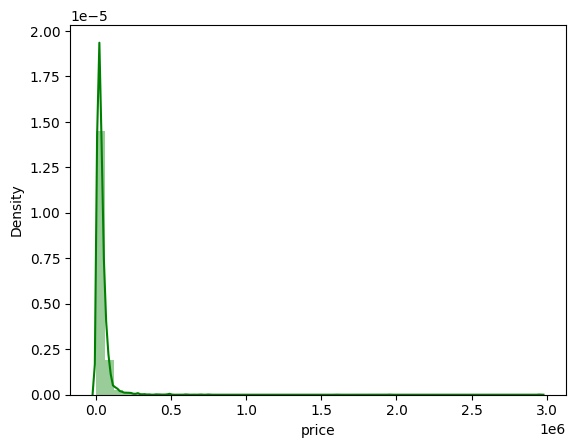

```python
#Plot Histogram for 'SalePrice'
print ("Skew is:", df1_train.price.skew())
print("Kurtosis : %f" % df1_train['price'].kurt())
sns.distplot(df1_train['price'], color = 'green')
plt.show()
```

The distribution is highly skewed to the right (positive skewness) and has very heavy tails with numerous outliers (very high kurtosis).

A skewness value of 23.62897359328672 indicates that the distribution is highly skewed. A positive skewness value suggests that the distribution has a tail on the right side that is longer than the left side as such the data points are stretched out more towards the higher values.

A kurtosis value of 825.930253 is extremely high, suggesting that the distribution has very heavy tails and potentially has many outliers. This high kurtosis indicates that the distribution has more extreme values (both high and low) than a normal distribution would.

```python
# function to plot a boxplot and a histogram along the same scale.
def histogram_boxplot(data, feature, figsize=(12, 7), kde=False, bins=None):
    """
    Boxplot and histogram combined

    data: dataframe
    feature: dataframe column
    figsize: size of figure (default (12,7))
    kde: whether to show the density curve (default False)
    bins: number of bins for histogram (default None)
    """
    f2, (ax_box2, ax_hist2) = plt.subplots(
        nrows=2,  # Number of rows of the subplot grid= 2
        sharex=True,  # x-axis will be shared among all subplots
        gridspec_kw={"height_ratios": (0.25, 0.75)},
        figsize=figsize,
    )  # creating the 2 subplots
    sns.boxplot(
        data=data, x=feature, ax=ax_box2, showmeans=True, color="violet"
    )  # boxplot will be created and a star will indicate the mean value of the column
    sns.histplot(
        data=data, x=feature, kde=kde, ax=ax_hist2, bins=bins, palette="winter"
    ) if bins else sns.histplot(
        data=data, x=feature, kde=kde, ax=ax_hist2
    )  # For histogram
    ax_hist2.axvline(
        data[feature].mean(), color="green", linestyle="--"
    )  # Add mean to the histogram
    ax_hist2.axvline(
        data[feature].median(), color="black", linestyle="-"
    )  # Add median to the histogram
```

```python
# function to create labeled barplots


def labeled_barplot(data, feature, perc=False, n=None):
    """
    Barplot with percentage at the top

    data: dataframe
    feature: dataframe column
    perc: whether to display percentages instead of count (default is False)
    n: displays the top n category levels (default is None, i.e., display all levels)
    """

    total = len(data[feature])  # length of the column
    count = data[feature].nunique()
    if n is None:
        plt.figure(figsize=(count + 1, 5))
    else:
        plt.figure(figsize=(n + 1, 5))

    plt.xticks(rotation=90, fontsize=15)
    ax = sns.countplot(
        data=data,
        x=feature,
        palette="Paired",
        order=data[feature].value_counts().index[:n].sort_values(),
    )

    for p in ax.patches:
        if perc == True:
            label = "{:.1f}%".format(
                100 * p.get_height() / total
            )  # percentage of each class of the category
        else:
            label = p.get_height()  # count of each level of the category

        x = p.get_x() + p.get_width() / 2  # width of the plot
        y = p.get_height()  # height of the plot

        ax.annotate(
            label,
            (x, y),
            ha="center",
            va="center",
            size=12,
            xytext=(0, 5),
            textcoords="offset points",
        )  # annotate the percentage

    plt.show()  # show the plot
```

```python
# function to plot stacked bar chart


def stacked_barplot(data, predictor, target):
    """
    Print the category counts and plot a stacked bar chart

    data: dataframe
    predictor: independent variable
    target: target variable
    """
    count = data[predictor].nunique()
    sorter = data[target].value_counts().index[-1]
    tab1 = pd.crosstab(data[predictor], data[target], margins=True).sort_values(
        by=sorter, ascending=False
    )
    print(tab1)
    print("-" * 120)
    tab = pd.crosstab(data[predictor], data[target], normalize="index").sort_values(
        by=sorter, ascending=False
    )
    tab.plot(kind="bar", stacked=True, figsize=(count + 1, 5))
    plt.legend(
        loc="lower left",
        frameon=False,
    )
    plt.legend(loc="upper left", bbox_to_anchor=(1, 1))
    plt.show()
```

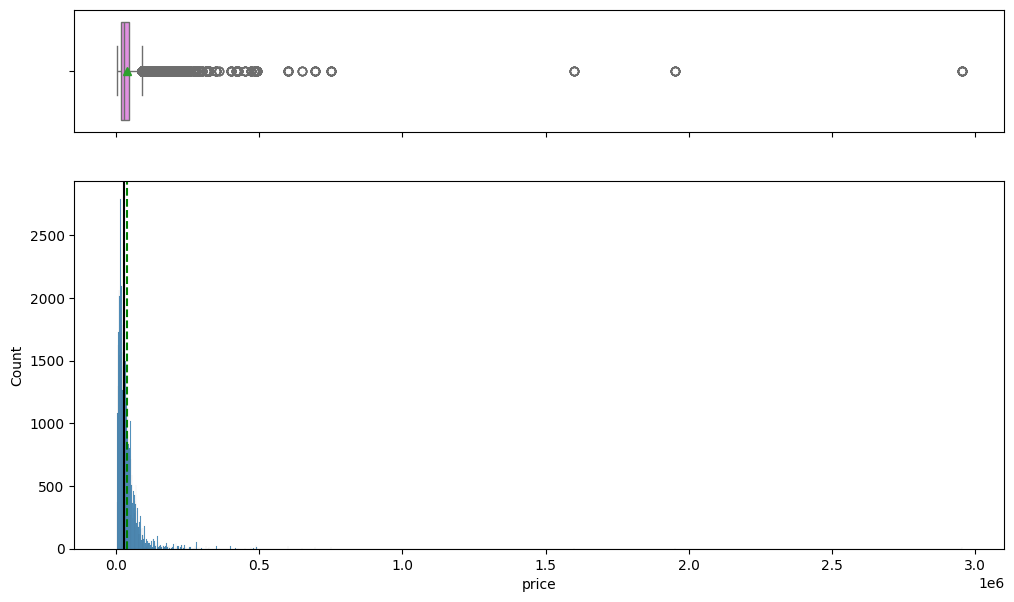

```python
# view distribution of price using of price
histogram_boxplot(df1_train, "price")
```

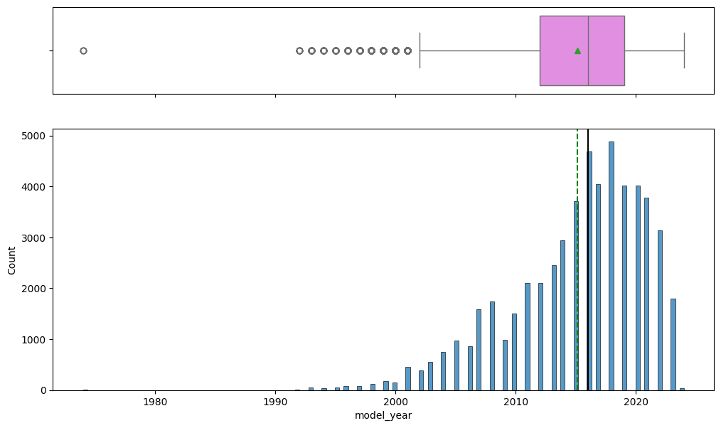

```python
histogram_boxplot(df1_train, "model_year")
```

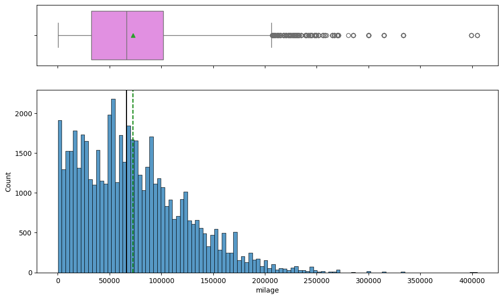

```python
histogram_boxplot(df1_train, "milage")
```

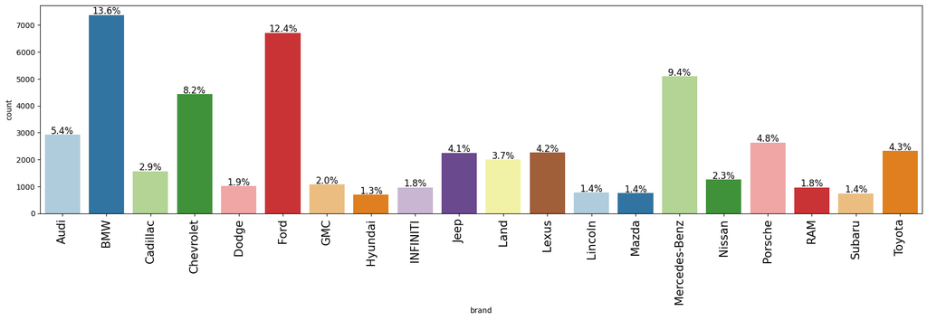

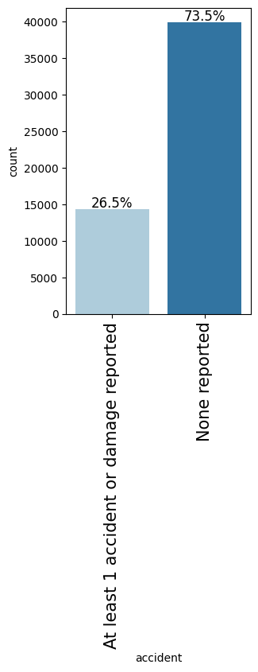

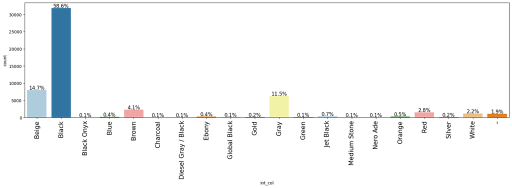

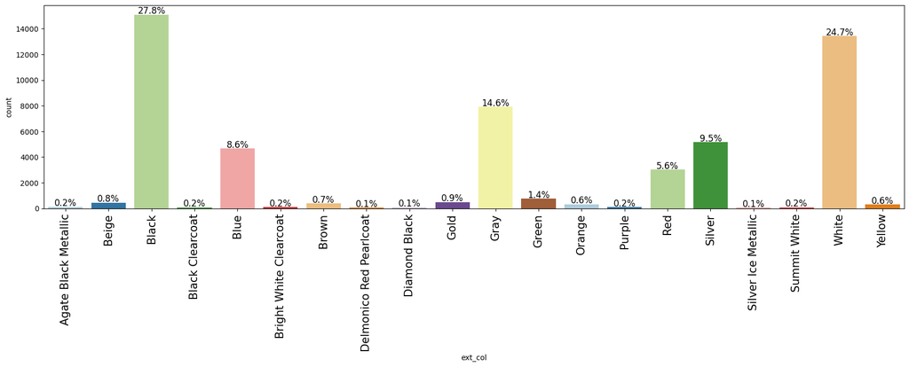

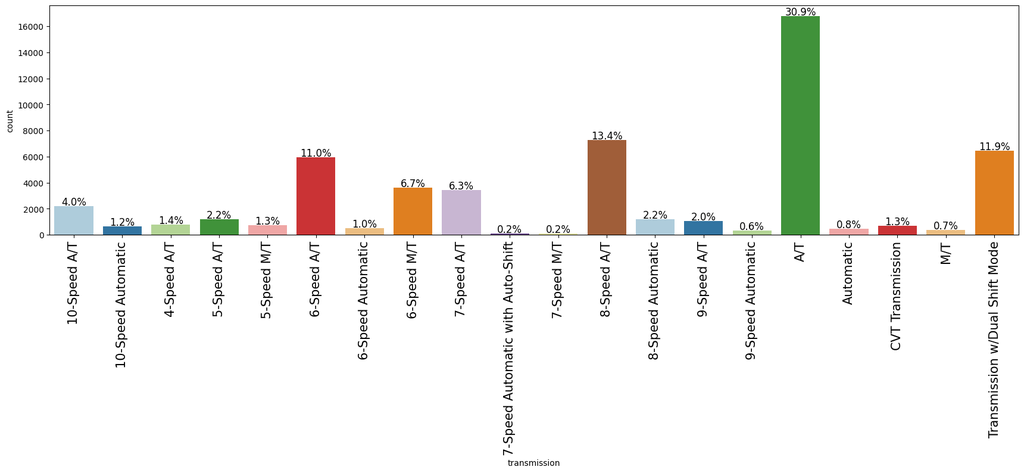

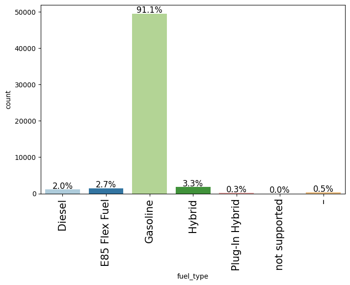

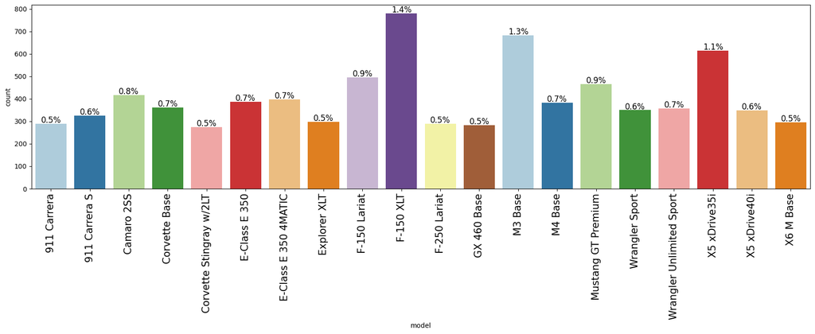

```python
# View distribution of categorical data
labeled_barplot(df1_train, "brand", perc=True, n=20)
labeled_barplot(df1_train, "accident", perc=True, n=2)
labeled_barplot(df1_train, "int_col", perc=True, n=20)
labeled_barplot(df1_train, "ext_col", perc=True, n=20)
labeled_barplot(df1_train, "transmission", perc=True, n=20)
labeled_barplot(df1_train, "fuel_type", perc=True, n=7)
labeled_barplot(df1_train, "model", perc=True, n=20)
```

```python
#Barplots of categorical variables and price
labeled_barplot(df1_train, "int_col", "price", n=20)
labeled_barplot(df1_train, "accident", "price", n=2)
labeled_barplot(df1_train, "ext_col", "price", n=10)
labeled_barplot(df1_train, "transmission", "price", n=20)
labeled_barplot(df1_train, "fuel_type", "price", n=7)
labeled_barplot(df1_train, "engine", "price", n=20)
labeled_barplot(df1_train, "model", "price", n=20)
```

[output not shown]

```python
df1_train.head(5)
```

|  | brand | model | model_year | milage | fuel_type | engine | transmission | ext_col | int_col | accident | price |
| --- | --- | --- | --- | --- | --- | --- | --- | --- | --- | --- | --- |
| 0 | Ford | F-150 Lariat | 2018 | 74349 | Gasoline | 375.0HP 3.5L V6 Cylinder Engine Gasoline Fuel | 10-Speed A/T | Blue | Gray | None reported | 11000 |
| 1 | BMW | 335 i | 2007 | 80000 | Gasoline | 300.0HP 3.0L Straight 6 Cylinder Engine Gasoli... | 6-Speed M/T | Black | Black | None reported | 8250 |
| 2 | Jaguar | XF Luxury | 2009 | 91491 | Gasoline | 300.0HP 4.2L 8 Cylinder Engine Gasoline Fuel | 6-Speed A/T | Purple | Beige | None reported | 15000 |
| 3 | BMW | X7 xDrive40i | 2022 | 2437 | Hybrid | 335.0HP 3.0L Straight 6 Cylinder Engine Gasoli... | Transmission w/Dual Shift Mode | Gray | Brown | None reported | 63500 |
| 4 | Pontiac | Firebird Base | 2001 | 111000 | Gasoline | 200.0HP 3.8L V6 Cylinder Engine Gasoline Fuel | A/T | White | Black | None reported | 7850 |

```python
df_test["years"] = 2024 - df_test["model_year"]
df_test.drop("model_year", axis=1, inplace=True)
df_test["years"].describe()
```

```python
df_test.shape
```

```
(36183, 11)
```

```python
df1_train["years"] = 2024 - df1_train["model_year"]
df1_train.drop("model_year", axis=1, inplace=True)
df1_train["years"].describe()
```

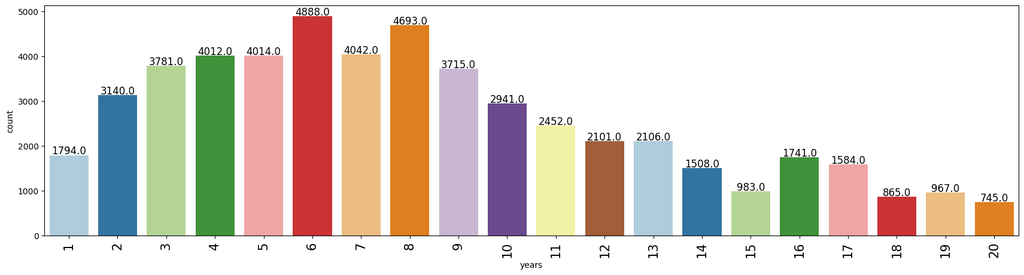

```python
labeled_barplot(df1_train, "years", "price", n=20)
```

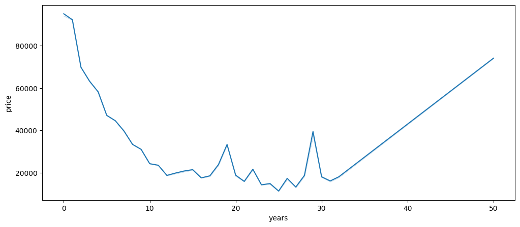

```python
plt.figure(figsize=(12, 5))
sns.lineplot(data=df1_train, x="years", y="price", ci=False)
plt.show()
```

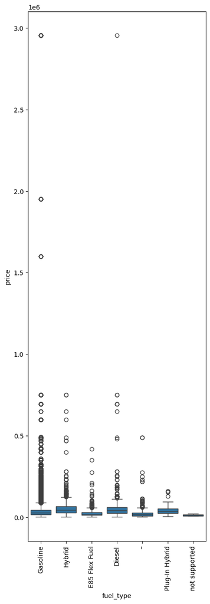

```python
# boxplot analysis for current price and Gics sector
plt.figure(figsize=(5,15))
sns.boxplot(data=df1_train,x='fuel_type',y='price')
plt.xticks(rotation=90)
plt.show()
```

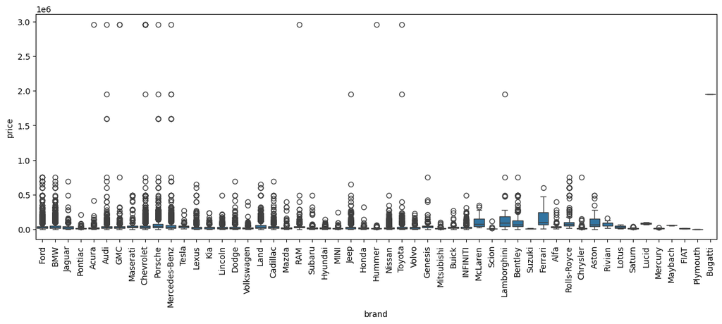

```python
plt.figure(figsize=(15, 5))
sns.boxplot(data=df1_train, x="brand", y="price")
plt.xticks(rotation=90)
plt.show()
```

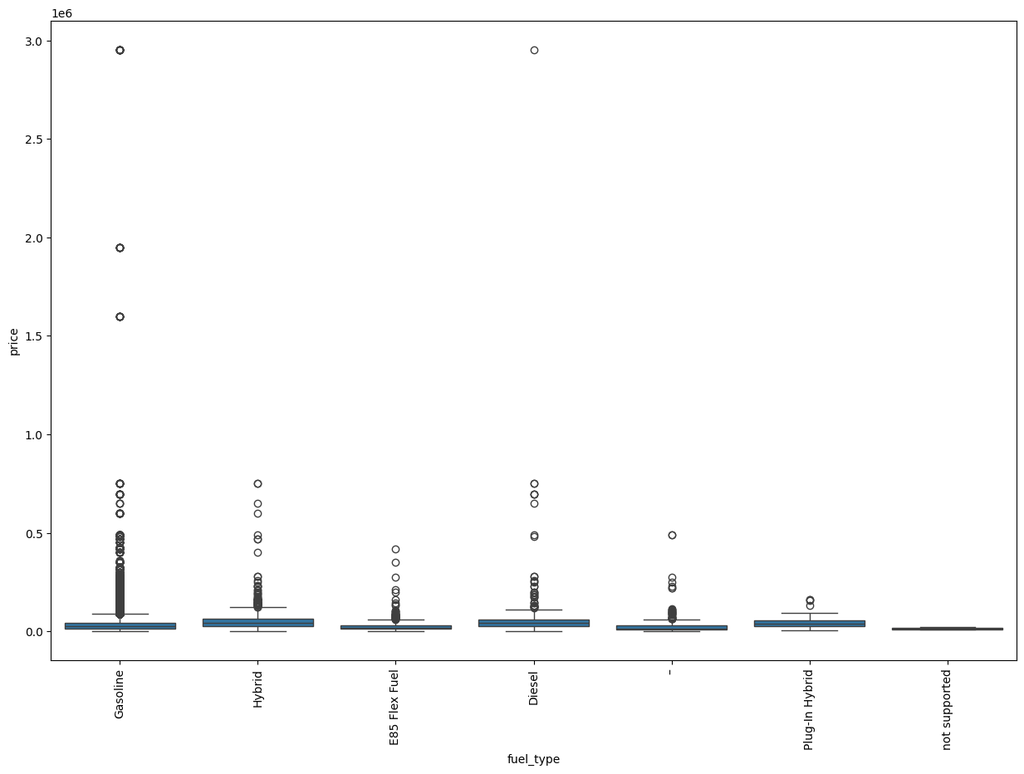

```python
plt.figure(figsize=(15, 10))
sns.boxplot(data=df1_train, x="fuel_type", y="price")
plt.xticks(rotation=90)
plt.show()
```

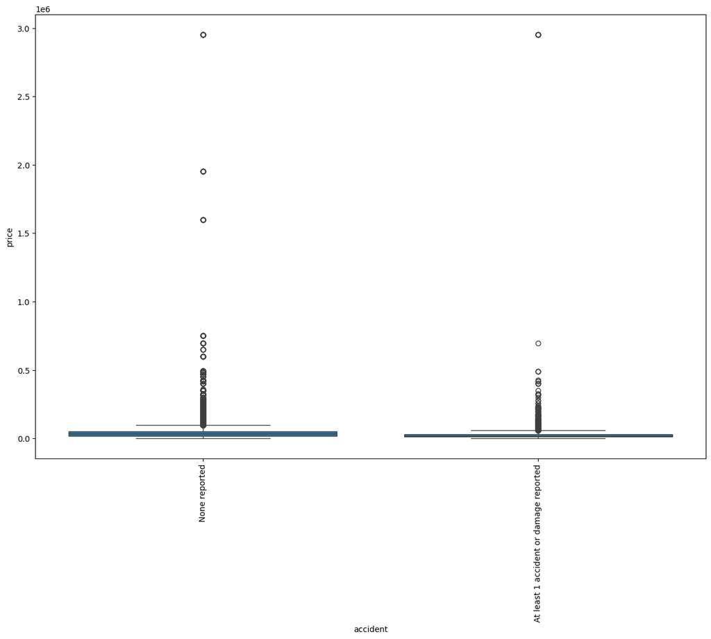

```python
plt.figure(figsize=(15, 10))
sns.boxplot(data=df1_train, x="accident", y="price")
plt.xticks(rotation=90)
plt.show()
```

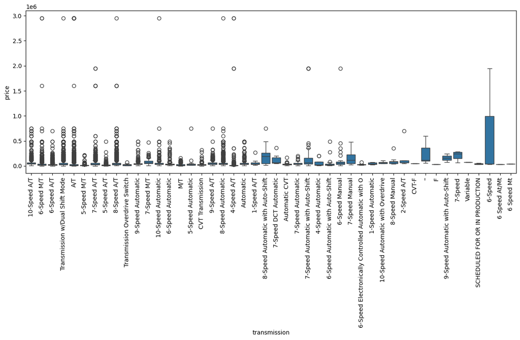

```python
plt.figure(figsize=(15, 5))
sns.boxplot(data=df1_train, x="transmission", y="price")
plt.xticks(rotation=90)
plt.show()
```

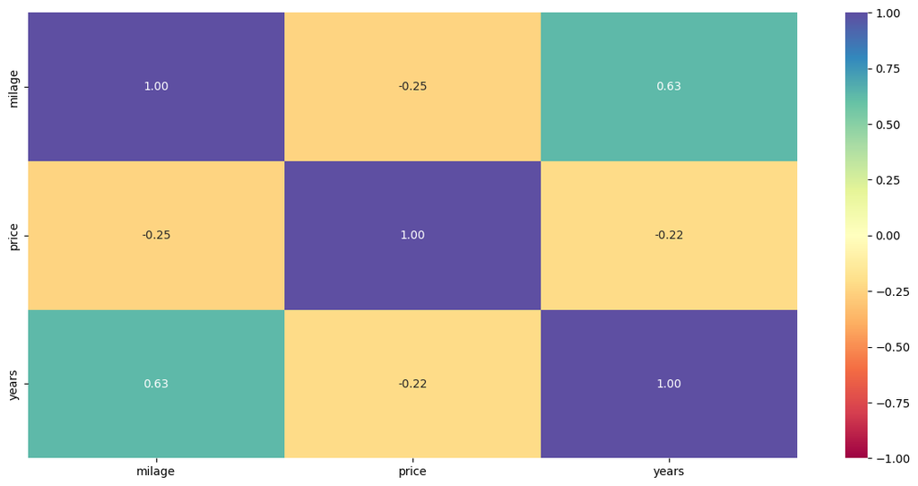

```python
cols_list = df1_train.select_dtypes(include=np.number).columns.tolist()
# dropping release_year as it is a temporal variable


plt.figure(figsize=(15, 7))
sns.heatmap(
    df1_train[cols_list].corr(), annot=True, vmin=-1, vmax=1, fmt=".2f", cmap="Spectral"
)
plt.show()
```

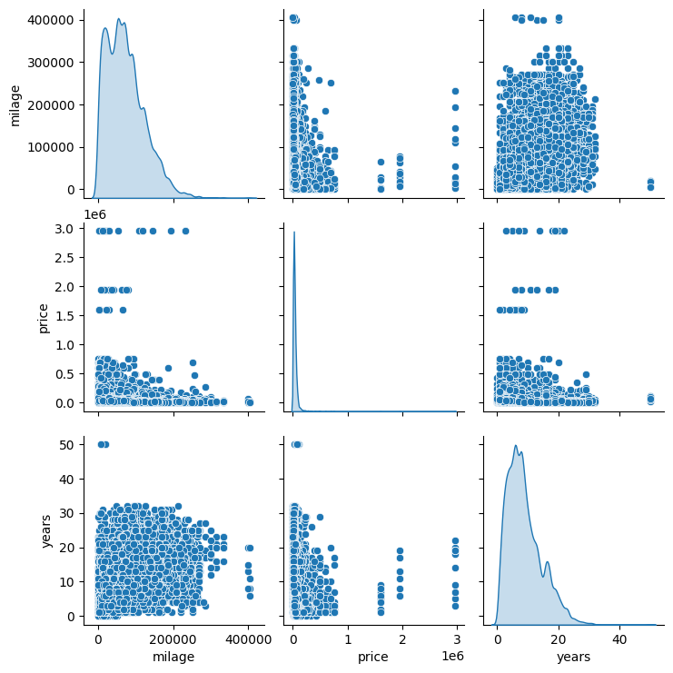

```python
sns.pairplot(data=df1_train[cols_list], diag_kind="kde")
plt.show()
```

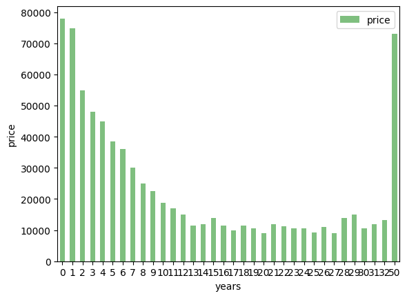

```python
# Compare 'price' and years
quality_pivot = df1_train.pivot_table(index='years', values='price', aggfunc=np.median)
quality_pivot.plot(kind='bar', color='green', alpha = 0.5)
plt.xlabel('years')
plt.ylabel('price')
plt.xticks(rotation=0)
plt.show()
```

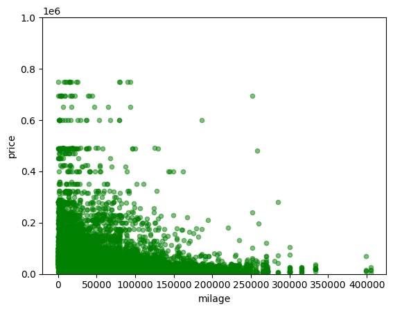

```python
#Analyse price milage
data = pd.concat([df1_train['price'], df1_train['milage']], axis = 1)
data.plot.scatter(x ='milage', y= 'price', ylim = (0,1000000), c= 'green', alpha = 0.5)
```

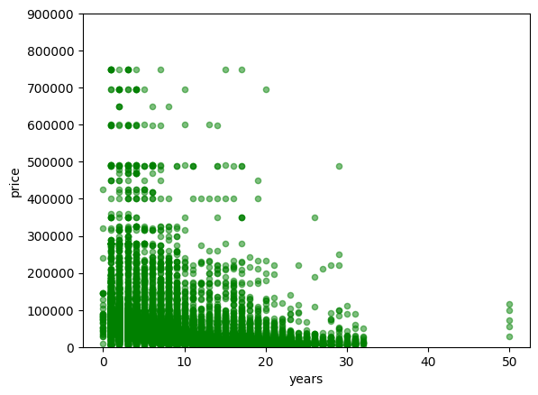

```python
#Analyse price milage
data = pd.concat([df1_train['price'], df1_train['years']], axis = 1)
data.plot.scatter(x ='years', y= 'price', ylim = (0,900000), c= 'green', alpha = 0.5)
```

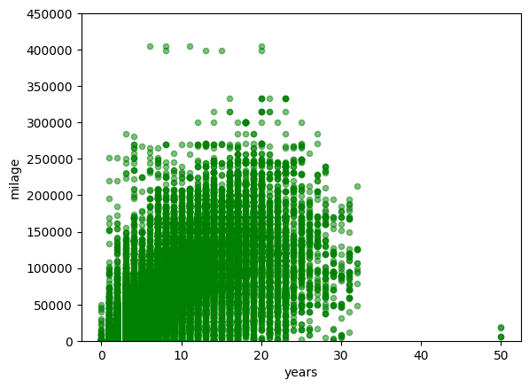

```python
#Analyse years and milage
data = pd.concat([df1_train['milage'], df1_train['years']], axis = 1)
data.plot.scatter(x ='years', y= 'milage', ylim = (0,450000), c= 'green', alpha = 0.5)
```

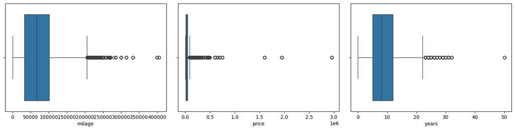

```python
# outlier detection using boxplot
num_cols = df1_train.select_dtypes(include=np.number).columns.tolist()

plt.figure(figsize=(15, 15))

for i, variable in enumerate(num_cols):
    plt.subplot(4, 3, i + 1)
    sns.boxplot(data=df1_train, x=variable)
    plt.tight_layout(pad=2)

plt.show()
```

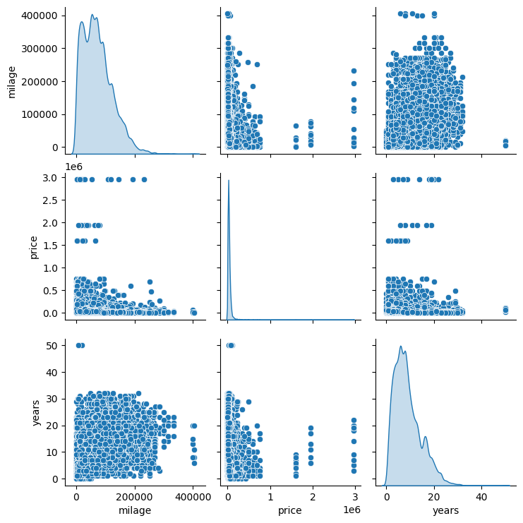

```python
sns.pairplot(data=df1_train[num_cols], diag_kind="kde")
plt.show()
```

```python
# defining the dependent and independent variables
X = df1_train.drop(["price"], axis=1)
y = df1_train["price"]

print(X.head())
print()
print(y.head())
```

Adding a constant to train data

```python
import pandas as pd
import numpy as np
from sklearn.model_selection import train_test_split, GridSearchCV
from sklearn.preprocessing import StandardScaler, OneHotEncoder
from sklearn.compose import ColumnTransformer
from sklearn.metrics import mean_squared_error
from tensorflow.keras.models import Sequential
from tensorflow.keras.layers import Dense, Dropout
from tensorflow.keras.wrappers.scikit_learn import KerasRegressor
```

```python
# let's add the intercept to data
X = sm.add_constant(X)
```

```python
# creating dummy variables for train data
X = pd.get_dummies(X,columns=X.select_dtypes(include=["object"]).columns.tolist(),drop_first=True,dtype=float)

X.head(10)
```

```python
X_large, X_test, y_large, y_test = train_test_split(X, y, test_size = 0.2, random_state = 42,shuffle = True)
```

```python
# Splitting the dataset into the Training and Val set in 80:20 ratio for train and val sets.

X_train, X_val, y_train, y_val = train_test_split(X_large, y_large, test_size = 0.2, random_state = 42, shuffle = True)
```

```python
print(X_train.shape, X_val.shape, X_test.shape)
```

```python
print(y_train.shape, y_val.shape, y_test.shape)
```

```python
# Data Normalization
# creating an instance of the standard scaler to normalize the x_train, x_validation and x_test data sets
sc = StandardScaler()
X_train = sc.fit_transform(X_train)
X_val = sc.transform(X_val)
X_test = sc.transform(X_test)
```

```python
backend.clear_session()
#Fixing the seed for random number generators so that we can ensure we receive the same output everytime
np.random.seed(2)
random.seed(2)
tf.random.set_seed(2)
```

```python
#Linear Regression
from sklearn import linear_model
from sklearn.metrics import r2_score
from sklearn.metrics import mean_squared_error

#Create linear regression
lm = linear_model.LinearRegression()

#Train the model using the training sets
lm.fit(X_train, y_train)

# Make predictions using the testing set
y_pred = lm.predict(X_val)
print('The accuracy of the Linear Regression is',r2_score(y_val,y_pred))
print ('RMSE is: ', mean_squared_error(y_val, y_pred))
```

```python
olsmodel1 = sm.OLS(y_train, X_train).fit()
print(olsmodel1.summary())
```

```python
def make_confusion_matrix(actual_targets, predicted_targets):
    """
    To plot the confusion_matrix with percentages

    actual_targets: actual target (dependent) variable values
    predicted_targets: predicted target (dependent) variable values
    """
    cm = confusion_matrix(actual_targets, predicted_targets)
    labels = np.asarray(
        [
            ["{0:0.0f}".format(item) + "\n{0:.2%}".format(item / cm.flatten().sum())]
            for item in cm.flatten()
        ]
    ).reshape(cm.shape[0], cm.shape[1])

    plt.figure(figsize=(6, 4))
    sns.heatmap(cm, annot=labels, fmt="")
    plt.ylabel("True label")
    plt.xlabel("Predicted label")
```

```python
from sklearn.metrics import r2_score
from sklearn.metrics import mean_squared_error
```

```python
# Creating two blank dataframes that will store the recall values for all the models we build.

train_metric_df = pd.DataFrame(columns=["r2_score"])
valid_metric_df = pd.DataFrame(columns=["r2_score"])
```

Initialize & build ANN model with SGD

```python
backend.clear_session()
#Fixing the seed for random number generators so that we can ensure we receive the same output everytime
np.random.seed(42)
random.seed(42)
tf.random.set_seed(42)
```

```python
#Initializing the neural network
model_0 = Sequential()
# Adding the input layer with 64 neurons and relu as activation function
model_0.add(Dense(64, activation='relu', input_dim = X_train.shape[1]))
# Code to add a hidden layer (specify the # of neurons and the activation function)
model_0.add(Dense(32, activation='relu'))
# Code to add the output layer with the number of neurons required.
model_0.add(Dense(1, activation = 'linear'))
```

```python
#Code to use SGD as the optimizer.
optimizer = tf.keras.optimizers.SGD(0.005)
```

```python
metric = keras.metrics.RootMeanSquaredError()
```

```python
# Code to compile the model with mean square error as loss function and RootMeanSquaredError as the metric
model_0.compile(loss = 'mse', optimizer=optimizer, metrics = [metric])
```

```python
# Model summary
model_0.summary()
```

```python
# Fitting the ANN
history_0 = model_0.fit(
    X_train, y_train,
    batch_size=50,
    validation_data=(X_val,y_val),
    epochs=20,
    verbose=1
)
```

```python
#Plotting Train Loss vs Validation Loss
plt.plot(history_0.history['loss'])
plt.plot(history_0.history['val_loss'])
plt.title('model loss')
plt.ylabel('Loss')
plt.xlabel('Epoch')
plt.legend(['train', 'validation'], loc='upper left')
plt.show()
```

[output not shown]

```python
#Plotting Train recall vs Validation recall
plt.plot(history_0.history['root_mean_squared_error'])
plt.plot(history_0.history['val_root_mean_squared_error'])
plt.title('model recall')
plt.ylabel('Recall')
plt.xlabel('Epoch')
plt.legend(['train', 'validation'], loc='upper left')
plt.show()
```

[output not shown]

```python
#Predicting the results using best as a threshold
y_train_pred = model_0.predict(X_train)
y_train_pred = (y_train_pred > 0.5)
y_train_pred
```

```python
y_val_pred = model_0.predict(X_val)
y_val_pred = (y_val_pred > 0.5)
y_val_pred
```

```python
model_name = "NN with SGD"

train_metric_df.loc[model_name] = r2_score(y_train, y_train_pred)
valid_metric_df.loc[model_name] = r2_score(y_val, y_val_pred)
```

Model 2

```python
# Libraries to help with reading and manipulating data
import numpy as np
import pandas as pd
# libaries to help with data visualization
import matplotlib.pyplot as pyplot
import matplotlib.pyplot as plt
import seaborn as sns
# Library to split data
from sklearn.model_selection import train_test_split
# library to import to standardize the data
from sklearn.preprocessing import StandardScaler
#To import different metrics
from sklearn.metrics import explained_variance_score, mean_squared_error, r2_score, mean_absolute_error
#Importing classback API
from keras import callbacks
# Importing tensorflow library
import tensorflow as tf
# importing different functions to build models
from tensorflow.keras.layers import Dense, Dropout,InputLayer
from tensorflow.keras.models import Sequential
# Importing Batch Normalization
from keras.layers import BatchNormalization
# Importing backend
from tensorflow.keras import backend
# Importing shffule
from random import shuffle
from keras.callbacks import ModelCheckpoint
# Importing optimizers
from tensorflow.keras.optimizers import Adam
from tensorflow.keras.optimizers import RMSprop
# Library to avoid the warnings
import warnings
warnings.filterwarnings("ignore")
```

```python
backend.clear_session()
#Fixing the seed for random number generators so that we can ensure we receive the same output everytime
np.random.seed(2)
random.seed(2)
tf.random.set_seed(2)
```

```python
#Initializing the neural network
model_1 = Sequential()
#Code to add a input layer (specify the # of neurons and activation function)
model_1.add(Dense(64,activation='relu',input_dim = X_train.shape[1]))
#Code to add a hidden layer (specify the # of neurons and activation function)
model_1.add(Dense(32,activation='relu'))
#Code to add a hidden layer (specify the # of neurons and activation function)
model_1.add(Dense(32,activation='relu'))
#Code to add a output layer with the required number of neurons and relu as activation function
model_1.add(Dense(1, activation = 'linear'))
```

```python
# Model summary
model_1.summary()
```

```python
#Code to use RMSprop as the optimizer
optimizer = tf.keras.optimizers.RMSprop(0.001)
```

```python
metric = keras.metrics.RootMeanSquaredError()
```

```python
# # Compiling the model with 'mse' as loss function and metrics
model_1.compile(loss = 'mse', optimizer=optimizer, metrics = [metric])
```

```python
# Fitting the ANN
history_1 = model_1.fit(
    X_train, y_train,
    batch_size=50,
    validation_data=(X_val,y_val),
    epochs=20,
    verbose=1
)
```

Neural Network with Adam Optimizer

```python
#Initializing the neural network
model_1 = Sequential()
# Adding the input layer with 128 neurons and relu as activation function
model_1.add(Dense(128, activation='relu', input_dim = X_train.shape[1]))
# Code to add a hidden layer (specify the # of neurons and the activation function)
model_1.add(Dense(64, activation='relu'))
# Code to add a hidden layer (specify the # of neurons and the activation function)
model_1.add(Dense(32, activation='relu'))
# Code to add the output layer with the number of neurons required.
model_1.add(Dense(1, activation = 'linear'))
```

```python
# Summary of the model
model_1.summary()
```

```python
#Code to use Adam as the optimizer.
optimizer = tf.keras.optimizers.Adam()
```

```python
backend.clear_session()
#Fixing the seed for random number generators so that we can ensure we receive the same output everytime
np.random.seed(2)
random.seed(2)
tf.random.set_seed(2)
```